# Credit Problem

Alan Arnholt

Last updated: October 26, 2021 at 12:53:07 PM

Read in the data:

```r
> Credit$Utilization <- Credit$Balance / (Credit$Income*100)
> DT::datatable(Credit[, -1], rownames = FALSE)
```

| Income | Limit | Rating | Cards | Age | Education | Gender | Student | Married | Ethnicity | Balance | Utilization |
| --- | --- | --- | --- | --- | --- | --- | --- | --- | --- | --- | --- |
| 14.891 | 3606 | 283 | 2 | 34 | 11 | Male | No | Yes | Caucasian | 333 | 0.223625008394332 |
| 106.025 | 6645 | 483 | 3 | 82 | 15 | Female | Yes | Yes | Asian | 903 | 0.0851685923131337 |
| 104.593 | 7075 | 514 | 4 | 71 | 11 | Male | No | No | Asian | 580 | 0.0554530417905596 |
| 148.924 | 9504 | 681 | 3 | 36 | 11 | Female | No | No | Asian | 964 | 0.0647310037334479 |
| 55.882 | 4897 | 357 | 2 | 68 | 16 | Male | No | Yes | Caucasian | 331 | 0.059231953043914 |
| 80.18 | 8047 | 569 | 4 | 77 | 10 | Male | No | No | Caucasian | 1151 | 0.14355200798204 |
| 20.996 | 3388 | 259 | 2 | 37 | 12 | Female | No | No | African American | 203 | 0.0966850828729282 |
| 71.408 | 7114 | 512 | 2 | 87 | 9 | Male | No | No | Asian | 872 | 0.122115169168721 |
| 15.125 | 3300 | 266 | 5 | 66 | 13 | Female | No | No | Caucasian | 279 | 0.184462809917355 |
| 71.061 | 6819 | 491 | 3 | 41 | 19 | Female | Yes | Yes | African American | 1350 | 0.189977624857517 |

[output cut: 390 more lines]

1. Create a model that predicts an individuals credit rating (`Rating`). Use both forward selection (store the model in `mod.fs`) and backwards elimination (store the model in `mod.be`) to create models. Evaluate your models for variance inflation and report the model you think is best.

```r
> library(MASS)
> mod.fs <- stepAIC(lm(Rating ~ 1, data = Credit), scope = .~Income + Limit + Cards + Age + Education + Gender + Student + Married + Ethnicity + Balance + Utilization, direction = "forward", test = "F")
```

```
Start:  AIC=4034.31
Rating ~ 1

              Df Sum of Sq     RSS    AIC F Value     Pr(F)
+ Limit        1   9492369   59516 2005.0   63478 < 2.2e-16 ***
+ Balance      1   7124258 2427627 3488.4    1168 < 2.2e-16 ***
+ Income       1   5982140 3569744 3642.6     667 < 2.2e-16 ***
+ Utilization  1    548579 9003306 4012.7      24 1.242e-06 ***
+ Age          1    101661 9450224 4032.0       4   0.03917 *
<none>                     9551885 4034.3
+ Cards        1     27074 9524811 4035.2       1   0.28814
+ Married      1     12901 9538984 4035.8       1   0.46358
+ Education    1      8675 9543210 4036.0       0   0.54786
+ Gender       1       754 9551131 4036.3       0   0.85940
+ Student      1        39 9551845 4036.3       0   0.96775
+ Ethnicity    2     19388 9532496 4037.5       0   0.66810
---
Signif. codes:  0 '***' 0.001 '**' 0.01 '*' 0.05 '.' 0.1 ' ' 1

Step:  AIC=2005.01
Rating ~ Limit

              Df Sum of Sq   RSS    AIC F Value   Pr(F)
+ Cards        1   17695.8 41820 1865.9 167.988 < 2e-16 ***
+ Balance      1     790.7 58725 2001.7   5.345 0.02129 *
+ Education    1     424.0 59092 2004.2   2.848 0.09224 .
+ Married      1     309.9 59206 2004.9   2.078 0.15023
<none>                     59516 2005.0
+ Utilization  1     171.1 59345 2005.9   1.145 0.28533
+ Student      1     150.5 59365 2006.0   1.006 0.31644
+ Income       1      79.5 59436 2006.5   0.531 0.46666
+ Age          1      64.8 59451 2006.6   0.433 0.51095
+ Gender       1       2.2 59514 2007.0   0.015 0.90307
+ Ethnicity    2     129.3 59386 2008.1   0.431 0.65013
---
Signif. codes:  0 '***' 0.001 '**' 0.01 '*' 0.05 '.' 0.1 ' ' 1

Step:  AIC=1865.87
Rating ~ Limit + Cards

```

[output cut: 39 more lines]

```
+ Age          1    20.276 41143 1865.3 0.19416 0.6597
+ Gender       1     0.123 41163 1865.5 0.00117 0.9727
+ Balance      1     0.004 41164 1865.5 0.00004 0.9952

Step:  AIC=1863
Rating ~ Limit + Cards + Married + Student + Education

              Df Sum of Sq   RSS    AIC F Value  Pr(F)
<none>                     40903 1863.0
+ Income       1   177.560 40726 1863.3 1.71343 0.1913
+ Utilization  1    91.021 40812 1864.1 0.87648 0.3497
+ Age          1    22.460 40881 1864.8 0.21592 0.6424
+ Ethnicity    2   218.573 40685 1864.9 1.05298 0.3499
+ Gender       1     0.031 40903 1865.0 0.00030 0.9863
+ Balance      1     0.019 40903 1865.0 0.00018 0.9892
```

```r
> mod.fs
```

```
Call:
lm(formula = Rating ~ Limit + Cards + Married + Student + Education,
    data = Credit)

Coefficients:
(Intercept)        Limit        Cards   MarriedYes   StudentYes    Education
   26.23209      0.06677      4.85206      2.17320      3.08807     -0.25985
```

```r
> mod.be <- stepAIC(lm(Rating ~ Income + Limit + Cards + Age + Education + Gender + Student + Married + Ethnicity + Balance + Utilization, data = Credit), direction = "backward", test = "F")
```

```
Start:  AIC=1867.55
Rating ~ Income + Limit + Cards + Age + Education + Gender +
    Student + Married + Ethnicity + Balance + Utilization

              Df Sum of Sq    RSS    AIC F Value   Pr(F)
- Utilization  1         0  39948 1865.5    0.00 0.96876
- Gender       1         5  39953 1865.6    0.05 0.83045
- Age          1        17  39966 1865.7    0.17 0.68106
- Ethnicity    2       247  40195 1866.0    1.19 0.30388
- Student      1        50  39998 1866.0    0.48 0.48731
<none>                      39948 1867.5
- Education    1       212  40160 1867.7    2.05 0.15278
- Married      1       521  40470 1870.7    5.05 0.02517 *
- Income       1       529  40477 1870.8    5.12 0.02418 *
- Balance      1       544  40492 1871.0    5.27 0.02221 *
- Cards        1     13957  53905 1985.4  135.21 < 2e-16 ***
- Limit        1    193415 233363 2571.6 1873.72 < 2e-16 ***
---
Signif. codes:  0 '***' 0.001 '**' 0.01 '*' 0.05 '.' 0.1 ' ' 1

Step:  AIC=1865.55
Rating ~ Income + Limit + Cards + Age + Education + Gender +
    Student + Married + Ethnicity + Balance

            Df Sum of Sq    RSS    AIC F Value     Pr(F)
- Gender     1         5  39953 1863.6    0.05  0.829024
- Age        1        18  39966 1863.7    0.17  0.678576
- Ethnicity  2       247  40195 1864.0    1.20  0.302124
- Student    1        53  40001 1864.1    0.51  0.474763
<none>                    39948 1865.5
- Education  1       212  40160 1865.7    2.06  0.152325
- Married    1       522  40470 1868.7    5.07  0.024954 *
- Balance    1       552  40500 1869.0    5.36  0.021122 *
- Income     1       720  40668 1870.7    6.99  0.008522 **
- Cards      1     14230  54178 1985.4  138.21 < 2.2e-16 ***
- Limit      1    202143 242091 2584.2 1963.32 < 2.2e-16 ***
---
Signif. codes:  0 '***' 0.001 '**' 0.01 '*' 0.05 '.' 0.1 ' ' 1

Step:  AIC=1863.6
```

[output cut: 48 more lines]

```
Signif. codes:  0 '***' 0.001 '**' 0.01 '*' 0.05 '.' 0.1 ' ' 1

Step:  AIC=1858.77
Rating ~ Income + Limit + Cards + Education + Married + Balance

            Df Sum of Sq    RSS    AIC F Value     Pr(F)
<none>                    40271 1858.8
- Education  1       238  40509 1859.1     2.3  0.128206
- Married    1       457  40728 1861.3     4.5  0.035339 *
- Balance    1       773  41044 1864.4     7.5  0.006293 **
- Income     1       879  41150 1865.4     8.6  0.003596 **
- Cards      1     15849  56120 1989.5   154.7 < 2.2e-16 ***
- Limit      1    520764 561035 2910.4  5082.1 < 2.2e-16 ***
---
Signif. codes:  0 '***' 0.001 '**' 0.01 '*' 0.05 '.' 0.1 ' ' 1
```

```r
> mod.be
```

```
Call:
lm(formula = Rating ~ Income + Limit + Cards + Education + Married +
    Balance, data = Credit)

Coefficients:
(Intercept)       Income        Limit        Cards    Education   MarriedYes
   30.57853      0.09803      0.06411      4.67871     -0.24806      2.20414
    Balance
    0.00859
```

```r
> # OR
> null <- lm(Rating ~ 1, data = Credit)
> full <- lm(Rating ~ ., data = Credit)
> mod.fs <- stepAIC(null, scope = list(lower = null, upper = full), direction = "forward", test = "F")
```

```
Start:  AIC=4034.31
Rating ~ 1

              Df Sum of Sq     RSS    AIC F Value     Pr(F)
+ Limit        1   9492369   59516 2005.0   63478 < 2.2e-16 ***
+ Balance      1   7124258 2427627 3488.4    1168 < 2.2e-16 ***
+ Income       1   5982140 3569744 3642.6     667 < 2.2e-16 ***
+ Utilization  1    548579 9003306 4012.7      24 1.242e-06 ***
+ Age          1    101661 9450224 4032.0       4   0.03917 *
<none>                     9551885 4034.3
+ Cards        1     27074 9524811 4035.2       1   0.28814
+ Married      1     12901 9538984 4035.8       1   0.46358
+ Education    1      8675 9543210 4036.0       0   0.54786
+ ID           1      4617 9547268 4036.1       0   0.66111
+ Gender       1       754 9551131 4036.3       0   0.85940
+ Student      1        39 9551845 4036.3       0   0.96775
+ Ethnicity    2     19388 9532496 4037.5       0   0.66810
---
Signif. codes:  0 '***' 0.001 '**' 0.01 '*' 0.05 '.' 0.1 ' ' 1

Step:  AIC=2005.01
Rating ~ Limit

              Df Sum of Sq   RSS    AIC F Value   Pr(F)
+ Cards        1   17695.8 41820 1865.9 167.988 < 2e-16 ***
+ Balance      1     790.7 58725 2001.7   5.345 0.02129 *
+ Education    1     424.0 59092 2004.2   2.848 0.09224 .
+ Married      1     309.9 59206 2004.9   2.078 0.15023
<none>                     59516 2005.0
+ Utilization  1     171.1 59345 2005.9   1.145 0.28533
+ Student      1     150.5 59365 2006.0   1.006 0.31644
+ Income       1      79.5 59436 2006.5   0.531 0.46666
+ Age          1      64.8 59451 2006.6   0.433 0.51095
+ ID           1      42.6 59473 2006.7   0.284 0.59409
+ Gender       1       2.2 59514 2007.0   0.015 0.90307
+ Ethnicity    2     129.3 59386 2008.1   0.431 0.65013
---
Signif. codes:  0 '***' 0.001 '**' 0.01 '*' 0.05 '.' 0.1 ' ' 1

Step:  AIC=1865.87
```

[output cut: 45 more lines]

```
+ Gender       1     0.123 41163 1865.5 0.00117 0.9727
+ Balance      1     0.004 41164 1865.5 0.00004 0.9952

Step:  AIC=1863
Rating ~ Limit + Cards + Married + Student + Education

              Df Sum of Sq   RSS    AIC F Value  Pr(F)
<none>                     40903 1863.0
+ Income       1   177.560 40726 1863.3 1.71343 0.1913
+ Utilization  1    91.021 40812 1864.1 0.87648 0.3497
+ Age          1    22.460 40881 1864.8 0.21592 0.6424
+ Ethnicity    2   218.573 40685 1864.9 1.05298 0.3499
+ ID           1     1.959 40901 1865.0 0.01883 0.8909
+ Gender       1     0.031 40903 1865.0 0.00030 0.9863
+ Balance      1     0.019 40903 1865.0 0.00018 0.9892
```

```r
> mod.be <- stepAIC(full, scope = list(lower = null, upper = full), direction = "backward", test = "F")
```

```
Start:  AIC=1869.41
Rating ~ ID + Income + Limit + Cards + Age + Education + Gender +
    Student + Married + Ethnicity + Balance + Utilization

              Df Sum of Sq    RSS    AIC F Value   Pr(F)
- Utilization  1         0  39935 1867.4    0.00 0.98454
- Gender       1         3  39938 1867.5    0.03 0.86352
- ID           1        13  39948 1867.5    0.13 0.71939
- Age          1        19  39954 1867.6    0.19 0.66532
- Ethnicity    2       252  40186 1867.9    1.22 0.29761
- Student      1        53  39988 1868.0    0.51 0.47463
<none>                      39935 1869.4
- Education    1       211  40146 1869.5    2.04 0.15378
- Married      1       525  40460 1872.6    5.07 0.02484 *
- Income       1       538  40473 1872.8    5.20 0.02314 *
- Balance      1       550  40485 1872.9    5.32 0.02167 *
- Cards        1     13854  53788 1986.5  133.91 < 2e-16 ***
- Limit        1    192631 232566 2572.2 1861.93 < 2e-16 ***
---
Signif. codes:  0 '***' 0.001 '**' 0.01 '*' 0.05 '.' 0.1 ' ' 1

Step:  AIC=1867.42
Rating ~ ID + Income + Limit + Cards + Age + Education + Gender +
    Student + Married + Ethnicity + Balance

            Df Sum of Sq    RSS    AIC F Value   Pr(F)
- Gender     1         3  39938 1865.5    0.03 0.86284
- ID         1        13  39948 1865.5    0.13 0.71784
- Age        1        20  39954 1865.6    0.19 0.66351
- Ethnicity  2       252  40187 1865.9    1.22 0.29606
- Student    1        55  39990 1866.0    0.54 0.46401
<none>                    39935 1867.4
- Education  1       211  40146 1867.5    2.05 0.15306
- Married    1       526  40460 1870.6    5.09 0.02458 *
- Balance    1       559  40493 1871.0    5.41 0.02049 *
- Income     1       728  40663 1872.6    7.05 0.00824 **
- Cards      1     14143  54077 1986.7  137.05 < 2e-16 ***
- Limit      1    201575 241510 2585.3 1953.43 < 2e-16 ***
---
Signif. codes:  0 '***' 0.001 '**' 0.01 '*' 0.05 '.' 0.1 ' ' 1
```

[output cut: 69 more lines]

```
Signif. codes:  0 '***' 0.001 '**' 0.01 '*' 0.05 '.' 0.1 ' ' 1

Step:  AIC=1858.77
Rating ~ Income + Limit + Cards + Education + Married + Balance

            Df Sum of Sq    RSS    AIC F Value     Pr(F)
<none>                    40271 1858.8
- Education  1       238  40509 1859.1     2.3  0.128206
- Married    1       457  40728 1861.3     4.5  0.035339 *
- Balance    1       773  41044 1864.4     7.5  0.006293 **
- Income     1       879  41150 1865.4     8.6  0.003596 **
- Cards      1     15849  56120 1989.5   154.7 < 2.2e-16 ***
- Limit      1    520764 561035 2910.4  5082.1 < 2.2e-16 ***
---
Signif. codes:  0 '***' 0.001 '**' 0.01 '*' 0.05 '.' 0.1 ' ' 1
```

```r
> summary(mod.fs)
```

```
Call:
lm(formula = Rating ~ Limit + Cards + Married + Student + Education,
    data = Credit)

Residuals:
     Min       1Q   Median       3Q      Max
-22.3855  -6.9708  -0.8064   6.4644  26.0040

Coefficients:
              Estimate Std. Error t value Pr(>|t|)
(Intercept) 26.2320857  2.8284022   9.275   <2e-16 ***
Limit        0.0667736  0.0002212 301.902   <2e-16 ***
Cards        4.8520572  0.3725931  13.022   <2e-16 ***
MarriedYes   2.1732013  1.0509888   2.068   0.0393 *
StudentYes   3.0880657  1.7086441   1.807   0.0715 .
Education   -0.2598468  0.1641332  -1.583   0.1142
---
Signif. codes:  0 '***' 0.001 '**' 0.01 '*' 0.05 '.' 0.1 ' ' 1

Residual standard error: 10.19 on 394 degrees of freedom
Multiple R-squared:  0.9957,    Adjusted R-squared:  0.9957
F-statistic: 1.832e+04 on 5 and 394 DF,  p-value: < 2.2e-16
```

```r
> summary(mod.be)
```

```
Call:
lm(formula = Rating ~ Income + Limit + Cards + Education + Married +
    Balance, data = Credit)

Residuals:
     Min       1Q   Median       3Q      Max
-24.3125  -7.0086  -0.7791   6.3904  26.4689

Coefficients:
              Estimate Std. Error t value Pr(>|t|)
(Intercept) 30.5785323  3.1546531   9.693  < 2e-16 ***
Income       0.0980282  0.0334651   2.929  0.00360 **
Limit        0.0641124  0.0008993  71.289  < 2e-16 ***
Cards        4.6787111  0.3762017  12.437  < 2e-16 ***
Education   -0.2480557  0.1627204  -1.524  0.12821
MarriedYes   2.2041378  1.0437511   2.112  0.03534 *
Balance      0.0085899  0.0031271   2.747  0.00629 **
---
Signif. codes:  0 '***' 0.001 '**' 0.01 '*' 0.05 '.' 0.1 ' ' 1

Residual standard error: 10.12 on 393 degrees of freedom
Multiple R-squared:  0.9958,    Adjusted R-squared:  0.9957
F-statistic: 1.547e+04 on 6 and 393 DF,  p-value: < 2.2e-16
```

```r
> car::vif(mod.be)
```

```
   Income     Limit     Cards Education   Married   Balance
 5.416696 16.778890  1.036249  1.006968  1.009329  8.048806
```

```r
> car::vif(mod.fs)
```

```
    Limit     Cards   Married   Student Education
 1.001692  1.003296  1.010116  1.012379  1.011255
```

I prefer `mod.fs` since it has less multicollinearity.

2. Create another model that predicts rating with `Limit`, `Cards`, `Married`, `Student`, and `Education` as features (store the model in `mod`).

```r
> mod <- lm(Rating ~ Limit + Cards + Married + Student + Education, data = Credit)
> summary(mod)
```

```
Call:
lm(formula = Rating ~ Limit + Cards + Married + Student + Education,
    data = Credit)

Residuals:
     Min       1Q   Median       3Q      Max
-22.3855  -6.9708  -0.8064   6.4644  26.0040

Coefficients:
              Estimate Std. Error t value Pr(>|t|)
(Intercept) 26.2320857  2.8284022   9.275   <2e-16 ***
Limit        0.0667736  0.0002212 301.902   <2e-16 ***
Cards        4.8520572  0.3725931  13.022   <2e-16 ***
MarriedYes   2.1732013  1.0509888   2.068   0.0393 *
StudentYes   3.0880657  1.7086441   1.807   0.0715 .
Education   -0.2598468  0.1641332  -1.583   0.1142
---
Signif. codes:  0 '***' 0.001 '**' 0.01 '*' 0.05 '.' 0.1 ' ' 1

Residual standard error: 10.19 on 394 degrees of freedom
Multiple R-squared:  0.9957,    Adjusted R-squared:  0.9957
F-statistic: 1.832e+04 on 5 and 394 DF,  p-value: < 2.2e-16
```

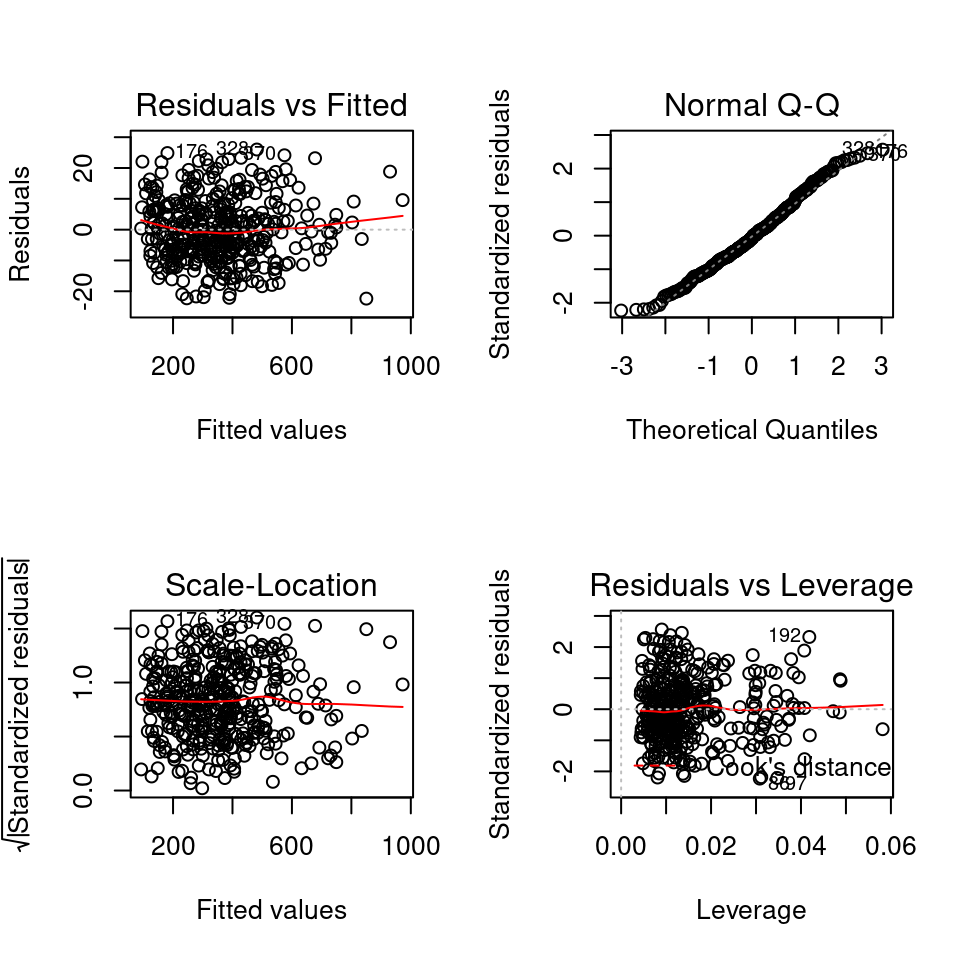

```r
> par(mfrow = c(2, 2))
> plot(mod)
```

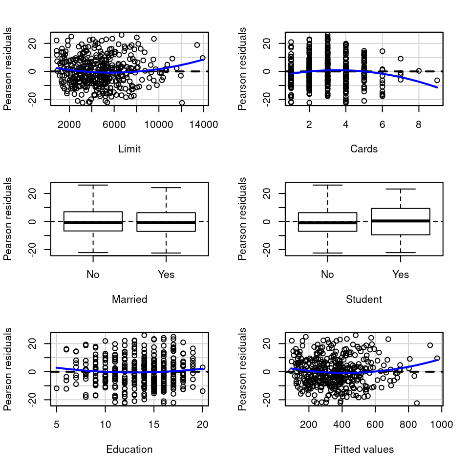

```
           Test stat Pr(>|Test stat|)
Limit         2.1566          0.03164 *
Cards        -2.2859          0.02279 *
Married
Student
Education     1.1741          0.24106
Tukey test    2.1146          0.03446 *
---
Signif. codes:  0 '***' 0.001 '**' 0.01 '*' 0.05 '.' 0.1 ' ' 1
```

```r
> par(mfrow = c(1, 1))
> car::residualPlots(mod)
```

```r
> modN <- lm(Rating ~ poly(Limit, 2, raw = TRUE) + poly(Cards, 2, raw = TRUE) + Married + Student + Education, data = Credit)
> summary(modN)
```

```
Call:
lm(formula = Rating ~ poly(Limit, 2, raw = TRUE) + poly(Cards,
    2, raw = TRUE) + Married + Student + Education, data = Credit)

Residuals:
     Min       1Q   Median       3Q      Max
-27.8814  -6.8317  -0.3358   6.5136  25.9925

Coefficients:
                              Estimate Std. Error t value Pr(>|t|)
(Intercept)                  2.579e+01  3.816e+00   6.760 5.01e-11 ***
poly(Limit, 2, raw = TRUE)1  6.529e-02  7.506e-04  86.984  < 2e-16 ***
poly(Limit, 2, raw = TRUE)2  1.320e-07  6.297e-08   2.096   0.0368 *
poly(Cards, 2, raw = TRUE)1  7.615e+00  1.301e+00   5.855 1.01e-08 ***
poly(Cards, 2, raw = TRUE)2 -3.972e-01  1.783e-01  -2.228   0.0264 *
MarriedYes                   2.295e+00  1.043e+00   2.199   0.0285 *
StudentYes                   3.159e+00  1.693e+00   1.866   0.0628 .
Education                   -2.774e-01  1.627e-01  -1.705   0.0889 .
---
Signif. codes:  0 '***' 0.001 '**' 0.01 '*' 0.05 '.' 0.1 ' ' 1

Residual standard error: 10.09 on 392 degrees of freedom
Multiple R-squared:  0.9958,    Adjusted R-squared:  0.9957
F-statistic: 1.334e+04 on 7 and 392 DF,  p-value: < 2.2e-16
```

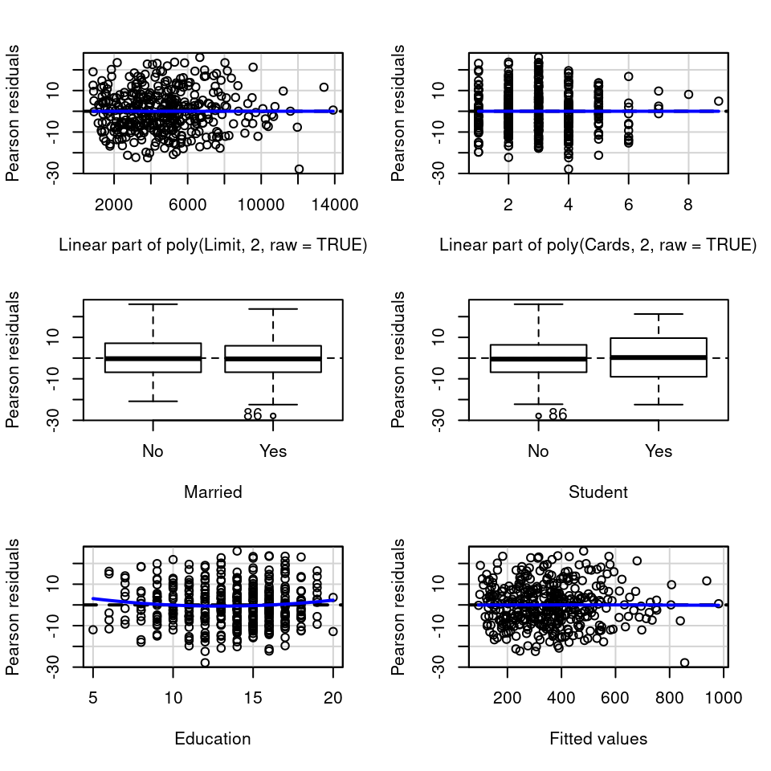

```
                           Test stat Pr(>|Test stat|)
poly(Limit, 2, raw = TRUE)
poly(Cards, 2, raw = TRUE)
Married
Student
Education                     1.2712           0.2044
Tukey test                   -0.7816           0.4345
```

```r
> car::residualPlots(modN)
```

```r
> car::vif(modN)
```

```
                               GVIF Df GVIF^(1/(2*Df))
poly(Limit, 2, raw = TRUE) 1.006987  2        1.001742
poly(Cards, 2, raw = TRUE) 1.011571  2        1.002880
Married                    1.014970  1        1.007457
Student                    1.012868  1        1.006413
Education                  1.012733  1        1.006346
```

```r
> summary(modN)
```

```
Call:
lm(formula = Rating ~ poly(Limit, 2, raw = TRUE) + poly(Cards,
    2, raw = TRUE) + Married + Student + Education, data = Credit)

Residuals:
     Min       1Q   Median       3Q      Max
-27.8814  -6.8317  -0.3358   6.5136  25.9925

Coefficients:
                              Estimate Std. Error t value Pr(>|t|)
(Intercept)                  2.579e+01  3.816e+00   6.760 5.01e-11 ***
poly(Limit, 2, raw = TRUE)1  6.529e-02  7.506e-04  86.984  < 2e-16 ***
poly(Limit, 2, raw = TRUE)2  1.320e-07  6.297e-08   2.096   0.0368 *
poly(Cards, 2, raw = TRUE)1  7.615e+00  1.301e+00   5.855 1.01e-08 ***
poly(Cards, 2, raw = TRUE)2 -3.972e-01  1.783e-01  -2.228   0.0264 *
MarriedYes                   2.295e+00  1.043e+00   2.199   0.0285 *
StudentYes                   3.159e+00  1.693e+00   1.866   0.0628 .
Education                   -2.774e-01  1.627e-01  -1.705   0.0889 .
---
Signif. codes:  0 '***' 0.001 '**' 0.01 '*' 0.05 '.' 0.1 ' ' 1

Residual standard error: 10.09 on 392 degrees of freedom
Multiple R-squared:  0.9958,    Adjusted R-squared:  0.9957
F-statistic: 1.334e+04 on 7 and 392 DF,  p-value: < 2.2e-16
```

3. Use your model from exercise 2 to predict the `Rating` for an individual who has a credit card limit of $6,000, has 4 credit cards, is married, is not a student, and has an undergraduate degree (`Education = 16`).

```r
> predict(mod, newdata = data.frame(Limit = 6000, Cards = 4, Married = "Yes", Student = "No", Education = 16))
```

```
       1
444.2975
```

```r
> predict(modN, newdata = data.frame(Limit = 6000, Cards = 4, Married = "Yes", Student = "No", Education = 16))
```

```
       1
444.2526
```

```r
> ### Should be the same as:
> coef(modN)[1] + coef(modN)[2]*6000 + coef(modN)[3]*6000^2 + coef(modN)[4]*4 + coef(modN)[5]*4^2 + coef(modN)[6]*1 + coef(modN)[7]*0 + coef(modN)[8]*16
```

```
(Intercept)
   444.2526
```

```r
> predict(modN, newdata = data.frame(Limit = 12000, Cards = 2, Married = "Yes", Student = "No", Education = 8), response = "pred")
```

```
       1
842.0091
```

4. Use your model to predict the `Rating` for an individual who has a credit card limit of $12,000, has 2 credit cards, is married, is not a student, and has an eighth grade education (`Education = 8`).

```r
> predict(mod, newdata = data.frame(Limit = 12000, Cards = 2, Married = "Yes", Student = "No", Education = 8))
```

```
       1
837.3137
```

Or using `modN`:

```r
> predict(modN, newdata = data.frame(Limit = 12000, Cards = 2, Married = "Yes", Student = "No", Education = 8))
```

```
       1
842.0091
```

5. Follow the linear algebra in Section 2.1.3 to develop 95% confidence intervals for the mean response (`Rating`) with the values from exercise 3 and exercise 4.

```r
> # Using predict function first:
> predict(mod, newdata = data.frame(Limit = 6000, Cards = 4, Married = "Yes", Student = "No", Education = 16), interval = "conf", level = 0.95)
```

```
       fit      lwr      upr
1 444.2975 442.4834 446.1116
```

```r
> X <- model.matrix(mod)
> XTXI <- solve(t(X)%*%X)
> XTXI
```

```
              (Intercept)         Limit         Cards    MarriedYes
(Intercept)  7.705835e-02 -2.281066e-06 -4.340522e-03 -5.190805e-03
Limit       -2.281066e-06  4.712103e-10 -7.337655e-09 -7.208450e-08
Cards       -4.340522e-03 -7.337655e-09  1.337233e-03  3.531631e-05
MarriedYes  -5.190805e-03 -7.208450e-08  3.531631e-05  1.063980e-02
StudentYes  -1.396238e-03  5.485929e-09  1.423578e-04  1.399399e-03
Education   -3.539037e-03  8.543275e-09  2.859010e-05 -9.138279e-05
               StudentYes     Education
(Intercept) -1.396238e-03 -3.539037e-03
Limit        5.485929e-09  8.543275e-09
Cards        1.423578e-04  2.859010e-05
MarriedYes   1.399399e-03 -9.138279e-05
StudentYes   2.812164e-02 -2.022349e-04
Education   -2.022349e-04  2.594959e-04
```

```r
> betahat <- coef(mod)
> betahat <- matrix(betahat, nrow = 6)
> dim(betahat)
```

```
[1] 6 1
```

```r
> # For 3
> Xh <- matrix(c(1, 6000, 4, 1, 0, 16), nrow = 1)
> (Yhath <- Xh %*%betahat)
```

```
         [,1]
[1,] 444.2975
```

```r
> anova(mod)
```

```
Analysis of Variance Table

Response: Rating
           Df  Sum Sq Mean Sq    F value  Pr(>F)
Limit       1 9492369 9492369 91434.8930 < 2e-16 ***
Cards       1   17696   17696   170.4546 < 2e-16 ***
Married     1     359     359     3.4545 0.06382 .
Student     1     298     298     2.8681 0.09114 .
Education   1     260     260     2.5064 0.11419
Residuals 394   40903     104
---
Signif. codes:  0 '***' 0.001 '**' 0.01 '*' 0.05 '.' 0.1 ' ' 1
```

```r
> MSE <- anova(mod)[6,3]
> varcovB <- MSE*XTXI
> (s2yhath <- Xh %*% varcovB %*% t(Xh))
```

```
          [,1]
[1,] 0.8514472
```

```r
> syhath <- sqrt(s2yhath)
> (crit_t <- qt(0.975, df.residual(mod)))
```

```
[1] 1.966003
```

```r
> CI_EYh <- c(Yhath - crit_t*syhath, Yhath + crit_t*syhath)
> CI_EYh
```

```
[1] 442.4834 446.1116
```

```r
> ######
> # For 4
>
> # Using predict function first:
> predict(mod, newdata = data.frame(Limit = 12000, Cards = 2, Married = "Yes", Student = "No", Education = 8), interval = "conf", level = 0.95)
```

```
       fit      lwr      upr
1 837.3137 833.4321 841.1952
```

```r
> ######
> Xh <- matrix(c(1, 12000, 2, 1, 0, 8), nrow = 1)
> (Yhath <- Xh %*%betahat)
```

```
         [,1]
[1,] 837.3137
```

```r
> MSE <- anova(mod)[6,3]
> varcovB <- MSE*XTXI
> (s2yhath <- Xh %*% varcovB %*% t(Xh))
```

```
         [,1]
[1,] 3.897998
```

```r
> syhath <- sqrt(s2yhath)
> (crit_t <- qt(0.975, df.residual(mod)))
```

```
[1] 1.966003
```

```r
> CI_EYh <- c(Yhath - crit_t*syhath, Yhath + crit_t*syhath)
> CI_EYh
```

```
[1] 833.4321 841.1952
```